# Part A: Data Cleaning

```python
import matplotlib.pyplot as plt
import pandas as pd
%matplotlib inline
import numpy as np
import seaborn as sns

from sklearn.model_selection import train_test_split
from sklearn.preprocessing import StandardScaler

from sklearn.linear_model import LinearRegression
from sklearn.metrics import mean_squared_error, r2_score, explained_variance_score
```

```python
# Step 1: Import dataset
data = pd.read_csv('bottle.csv')
```

```python
# Verify that the shape is: (864863, 74)
print("Shape of dataset:", data.shape)
```

```
Shape of dataset: (864863, 74)
```

```python
# Step 2: Limit dataset to specified columns and remove NaN and NA values
columns_to_keep = ['T_degC', 'Salnty', 'STheta', 'O2ml_L', 'Depthm']
data = data[columns_to_keep].dropna()
```

```python
# Verify the new shape is (661268, 5)
print("Shape after removing NaN and NA values:", data.shape)
```

```
Shape after removing NaN and NA values: (661268, 5)
```

```python
# Step 3: Remove any STheta outliers. Build scatter plots using Matplotlib.
data.head(5)
```

|  | T_degC | Salnty | STheta | O2ml_L | Depthm |
| --- | --- | --- | --- | --- | --- |
| 2160 | 10.30 | 33.030 | 25.364 | 5.90 | 0 |
| 2161 | 18.46 | 32.920 | 23.568 | 6.02 | 6 |
| 2162 | 10.29 | 32.951 | 25.304 | 6.04 | 10 |
| 2163 | 10.29 | 32.990 | 25.335 | 6.06 | 15 |
| 2164 | 10.33 | 33.005 | 25.339 | 6.04 | 20 |

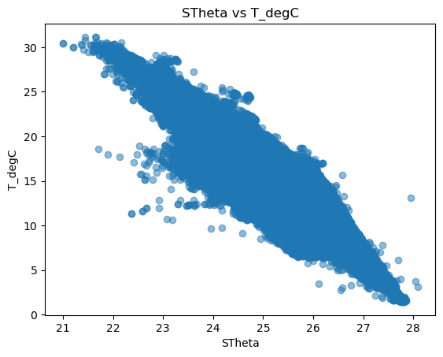

```python
# Scatter plot: STheta vs T_degC
plt.scatter(data['STheta'], data['T_degC'], alpha=0.5)
plt.title('STheta vs T_degC')
plt.xlabel('STheta')
plt.ylabel('T_degC')
```

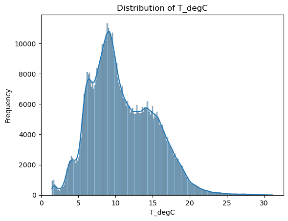

```python
# Distribution of T_degC (hint: distplot will be helpful here)
sns.histplot(data['T_degC'], kde=True)
plt.title('Distribution of T_degC')
plt.xlabel('T_degC')
plt.ylabel('Frequency')
plt.show()
```

```python
# Remove outliers from STheta column
data_clean = data[(data['STheta'] <= 50)]
```

```python
# Verify shape of clean data. Outliers for STheta might have been removed due to NAs in new features.
#  Shape for clean data will be: (661268, 5)
print("Shape of clean data after removing outliers:", data_clean.shape)
```

```
Shape of clean data after removing outliers: (661268, 5)
```

# Part B: Train/Test Split & Scaling

```python
data_clean.head(5)
```

|  | T_degC | Salnty | STheta | O2ml_L | Depthm |
| --- | --- | --- | --- | --- | --- |
| 2160 | 10.30 | 33.030 | 25.364 | 5.90 | 0 |
| 2161 | 18.46 | 32.920 | 23.568 | 6.02 | 6 |
| 2162 | 10.29 | 32.951 | 25.304 | 6.04 | 10 |
| 2163 | 10.29 | 32.990 | 25.335 | 6.06 | 15 |
| 2164 | 10.33 | 33.005 | 25.339 | 6.04 | 20 |

```python
# Step 1: Create X & y objects
X = data_clean[['Salnty', 'STheta', 'O2ml_L', 'Depthm']]
y = data_clean['T_degC'].values.reshape(-1, 1)  # Reshape y to a 2D array
```

```python
# Step 2: Generate X_train, X_test, y_train & y_test
X_train, X_test, y_train, y_test = train_test_split(X, y, test_size=0.2, random_state=42)
```

```python
# Step 3: Scale all features
scaler = StandardScaler()
X_train_scaled = scaler.fit_transform(X_train)  # Fit scaler to training data and transform X_train
X_test_scaled = scaler.transform(X_test)        # Transform X_test using scaling parameters learned from training data
```

```python
X_train
```

|  | Salnty | STheta | O2ml_L | Depthm |
| --- | --- | --- | --- | --- |
| 372952 | 33.3960 | 25.46400 | 5.090 | 150 |
| 677562 | 34.1210 | 26.68400 | 1.640 | 318 |
| 249296 | 33.1900 | 24.79600 | 5.880 | 28 |
| 835443 | 33.1699 | 25.31971 | 6.730 | 30 |
| 50621 | 33.5700 | 23.87100 | 4.970 | 0 |
| ... | ... | ... | ... | ... |
| 847186 | 33.6446 | 25.83848 | 3.461 | 125 |
| 350374 | 34.3100 | 26.60200 | 0.970 | 295 |
| 549696 | 33.3460 | 24.58900 | 5.800 | 18 |
| 211783 | 34.5030 | 27.28400 | 0.250 | 800 |
| 200191 | 33.1900 | 25.98500 | 5.720 | 124 |

529014 rows × 4 columns

```python
X_train_scaled
```

```
array([[-0.94801805, -0.33072186,  0.80884944, -0.22441603],
       [ 0.62640206,  0.87719897, -0.85837645,  0.31487462],
       [-1.39537053, -0.99210802,  1.19062   , -0.61604377],
       ...,
       [-1.05659875, -1.19705852,  1.15195969, -0.6481444 ],
       [ 1.45595859,  1.4712584 , -1.53009935,  1.86212518],
       [-1.39537053,  0.18511974,  1.11329938, -0.30787768]])
```

# Part C: Linear Regression with sklearn

```python
# Step 1: Create an instance of LinearRegression and fit the model
lin_reg = LinearRegression()
lin_reg.fit(X_train_scaled, y_train)
```

```
LinearRegression()
```

```python
# Step 2: Print out coefficients (including intercept)
print("Intercept:", lin_reg.intercept_)
print("Coefficients:", lin_reg.coef_)
```

```
Intercept: [10.91541795]
Coefficients: [[ 1.63046569 -4.6345913   0.3020677  -0.47495536]]
```

```python
# Step 3: Predict T_degC for the test data
y_pred_sklearn = lin_reg.predict(X_test_scaled)
```

```python
# Step 4: Calculate evaluation metrics
mse = mean_squared_error(y_test, y_pred_sklearn)
r_squared = r2_score(y_test, y_pred_sklearn)
explained_variance = explained_variance_score(y_test, y_pred_sklearn)

print("Mean Squared Error:", mse)
print("R-squared:", r_squared)
print("Explained Variance Score:", explained_variance)
```

```
Mean Squared Error: 0.11101117205433625
R-squared: 0.9937682503632342
Explained Variance Score: 0.9937684088237414
```

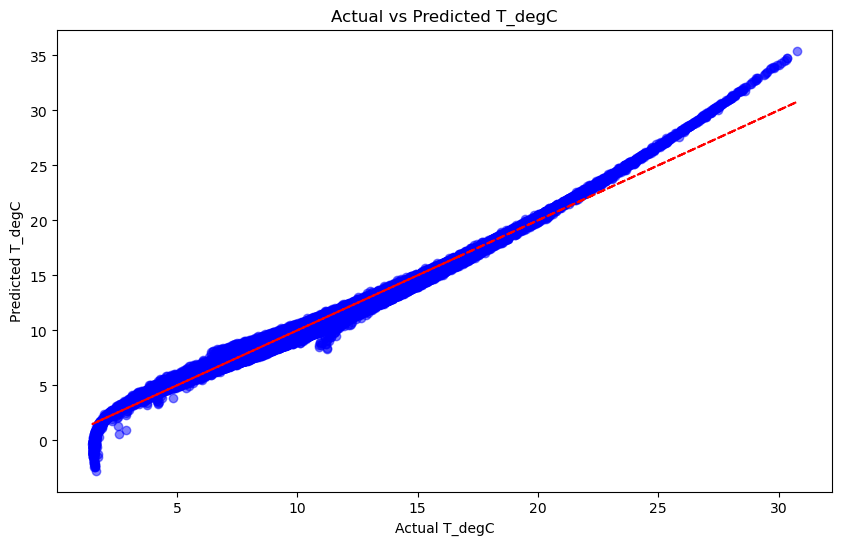

```python
# Step 5: Create a scatterplot of actual versus predicted values
plt.figure(figsize=(10, 6))
plt.scatter(y_test, y_pred_sklearn, color='blue', alpha=0.5)
plt.plot(y_test, y_test, color='red', linestyle='--')  # Plot y = x line for reference
plt.title('Actual vs Predicted T_degC')
plt.xlabel('Actual T_degC')
plt.ylabel('Predicted T_degC')
plt.show()
```

# Part D: Gradient Descent Mini-Batch

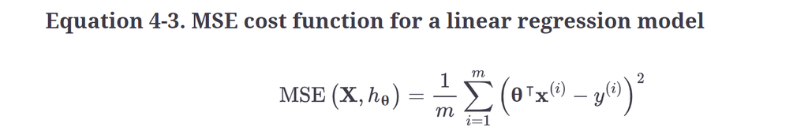

### min- batch 50

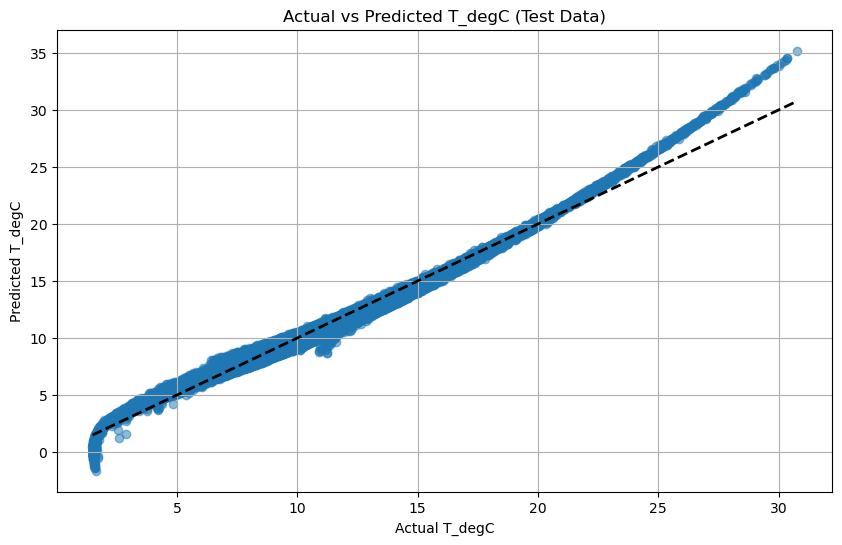

```
theta: [[10.92245743]
 [ 1.6307309 ]
 [-4.59254904]
 [ 0.29717947]
 [-0.4104474 ]]

Training Data Metrics:
Mean Squared Error: 0.12097799394061944
R-squared: 0.9932243413168341
Explained Variance Score: 0.9932271167249732

Test Data Metrics:
Mean Squared Error: 0.12121530275486025
R-squared: 0.9931954288479784
Explained Variance Score: 0.9931969171603586
```

```python
# min- batch 500
# Function to perform Mini-Batch Gradient Descent

def mini_batch_gradient_descent(X_train, y_train, X_test, y_test, eta=0.1, epochs=100, batch_size=50):
    # Add a column of 1s to X_train and X_test
    X_train = np.hstack((np.ones((X_train.shape[0], 1)), X_train))
    X_test = np.hstack((np.ones((X_test.shape[0], 1)), X_test))

    # Initialize parameters
    theta = np.random.randn(X_train.shape[1], 1)
    m = len(X_train)

    # Lists to store metrics
    mse_train_list = []
    r2_train_list = []
    ev_train_list = []
    mse_test_list = []
    r2_test_list = []
    ev_test_list = []

    # Mini-Batch Gradient Descent
    for epoch in range(epochs):
        shuffled_indices = np.random.permutation(m)
        X_train_shuffled = X_train[shuffled_indices]
        y_train_shuffled = y_train[shuffled_indices]
        for i in range(0, m, batch_size):
            xi = X_train_shuffled[i:i+batch_size]
            yi = y_train_shuffled[i:i+batch_size]
            gradients = 2/batch_size * xi.T.dot(xi.dot(theta) - yi)
            theta -= eta * gradients

        # Calculate metrics for training data
        y_pred_train = X_train.dot(theta)
        mse_train = mean_squared_error(y_train, y_pred_train)
        r2_train = r2_score(y_train, y_pred_train)
        ev_train = explained_variance_score(y_train, y_pred_train)
        mse_train_list.append(mse_train)
        r2_train_list.append(r2_train)
        ev_train_list.append(ev_train)

        # Calculate metrics for test data
        y_pred_test = X_test.dot(theta)
        mse_test = mean_squared_error(y_test, y_pred_test)
        r2_test = r2_score(y_test, y_pred_test)
        ev_test = explained_variance_score(y_test, y_pred_test)
        mse_test_list.append(mse_test)
        r2_test_list.append(r2_test)
        ev_test_list.append(ev_test)

    return {'mse_train': mse_train_list, 'r2_train': r2_train_list, 'ev_train': ev_train_list,
            'mse_test': mse_test_list, 'r2_test': r2_test_list, 'ev_test': ev_test_list,
            'theta': theta}




# Perform Mini-Batch Gradient Descent
result = mini_batch_gradient_descent(X_train_scaled, y_train, X_test_scaled, y_test)

# Add a column of ones to X_test_scaled
X_test_scaled_with_intercept = np.hstack((np.ones((X_test_scaled.shape[0], 1)), X_test_scaled))

# Calculate predictions for the test data using the updated X_test_scaled
y_pred_test = X_test_scaled_with_intercept.dot(result['theta'])

# Plot actual versus predicted values for T_degC for the test data
plt.figure(figsize=(10, 6))
plt.scatter(y_test, y_pred_test, alpha=0.5)
plt.plot([min(y_test), max(y_test)], [min(y_test), max(y_test)], 'k--', lw=2)
plt.title('Actual vs Predicted T_degC (Test Data)')
plt.xlabel('Actual T_degC')
plt.ylabel('Predicted T_degC')
plt.grid(True)
plt.show()

# Print final metrics

print("theta:", result['theta'])

print("\nTraining Data Metrics:")
print("Mean Squared Error:", result['mse_train'][-1])
print("R-squared:", result['r2_train'][-1])
print("Explained Variance Score:", result['ev_train'][-1])
print("\nTest Data Metrics:")
print("Mean Squared Error:", result['mse_test'][-1])
print("R-squared:", result['r2_test'][-1])
print("Explained Variance Score:", result['ev_test'][-1])
```

### min- batch 250

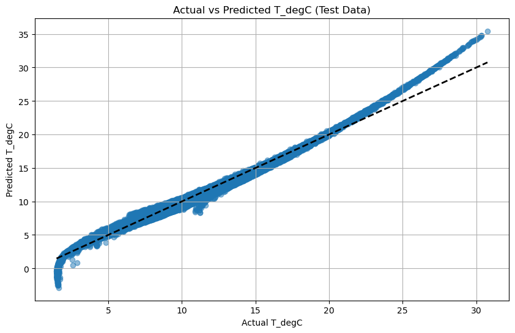

```
theta: [[10.91650379]
 [ 1.63588269]
 [-4.63900848]
 [ 0.29998962]
 [-0.48143467]]

Training Data Metrics:
Mean Squared Error: 0.1106444067727708
R-squared: 0.9938030983067744
Explained Variance Score: 0.9938031643427201

Test Data Metrics:
Mean Squared Error: 0.11102176246804374
R-squared: 0.993767655857244
Explained Variance Score: 0.993767673284259
```

```python
# min- batch 500
# Function to perform Mini-Batch Gradient Descent

def mini_batch_gradient_descent(X_train, y_train, X_test, y_test, eta=0.1, epochs=100, batch_size=250):
    # Add a column of 1s to X_train and X_test
    X_train = np.hstack((np.ones((X_train.shape[0], 1)), X_train))
    X_test = np.hstack((np.ones((X_test.shape[0], 1)), X_test))

    # Initialize parameters
    theta = np.random.randn(X_train.shape[1], 1)
    m = len(X_train)

    # Lists to store metrics
    mse_train_list = []
    r2_train_list = []
    ev_train_list = []
    mse_test_list = []
    r2_test_list = []
    ev_test_list = []

    # Mini-Batch Gradient Descent
    for epoch in range(epochs):
        shuffled_indices = np.random.permutation(m)
        X_train_shuffled = X_train[shuffled_indices]
        y_train_shuffled = y_train[shuffled_indices]
        for i in range(0, m, batch_size):
            xi = X_train_shuffled[i:i+batch_size]
            yi = y_train_shuffled[i:i+batch_size]
            gradients = 2/batch_size * xi.T.dot(xi.dot(theta) - yi)
            theta -= eta * gradients

        # Calculate metrics for training data
        y_pred_train = X_train.dot(theta)
        mse_train = mean_squared_error(y_train, y_pred_train)
        r2_train = r2_score(y_train, y_pred_train)
        ev_train = explained_variance_score(y_train, y_pred_train)
        mse_train_list.append(mse_train)
        r2_train_list.append(r2_train)
        ev_train_list.append(ev_train)

        # Calculate metrics for test data
        y_pred_test = X_test.dot(theta)
        mse_test = mean_squared_error(y_test, y_pred_test)
        r2_test = r2_score(y_test, y_pred_test)
        ev_test = explained_variance_score(y_test, y_pred_test)
        mse_test_list.append(mse_test)
        r2_test_list.append(r2_test)
        ev_test_list.append(ev_test)

    return {'mse_train': mse_train_list, 'r2_train': r2_train_list, 'ev_train': ev_train_list,
            'mse_test': mse_test_list, 'r2_test': r2_test_list, 'ev_test': ev_test_list,
            'theta': theta}




# Perform Mini-Batch Gradient Descent
result = mini_batch_gradient_descent(X_train_scaled, y_train, X_test_scaled, y_test)

# Add a column of ones to X_test_scaled
X_test_scaled_with_intercept = np.hstack((np.ones((X_test_scaled.shape[0], 1)), X_test_scaled))

# Calculate predictions for the test data using the updated X_test_scaled
y_pred_test = X_test_scaled_with_intercept.dot(result['theta'])

# Plot actual versus predicted values for T_degC for the test data
plt.figure(figsize=(10, 6))
plt.scatter(y_test, y_pred_test, alpha=0.5)
plt.plot([min(y_test), max(y_test)], [min(y_test), max(y_test)], 'k--', lw=2)
plt.title('Actual vs Predicted T_degC (Test Data)')
plt.xlabel('Actual T_degC')
plt.ylabel('Predicted T_degC')
plt.grid(True)
plt.show()

# Print final metrics

print("theta:", result['theta'])

print("\nTraining Data Metrics:")
print("Mean Squared Error:", result['mse_train'][-1])
print("R-squared:", result['r2_train'][-1])
print("Explained Variance Score:", result['ev_train'][-1])
print("\nTest Data Metrics:")
print("Mean Squared Error:", result['mse_test'][-1])
print("R-squared:", result['r2_test'][-1])
print("Explained Variance Score:", result['ev_test'][-1])
```

### min- batch 2000

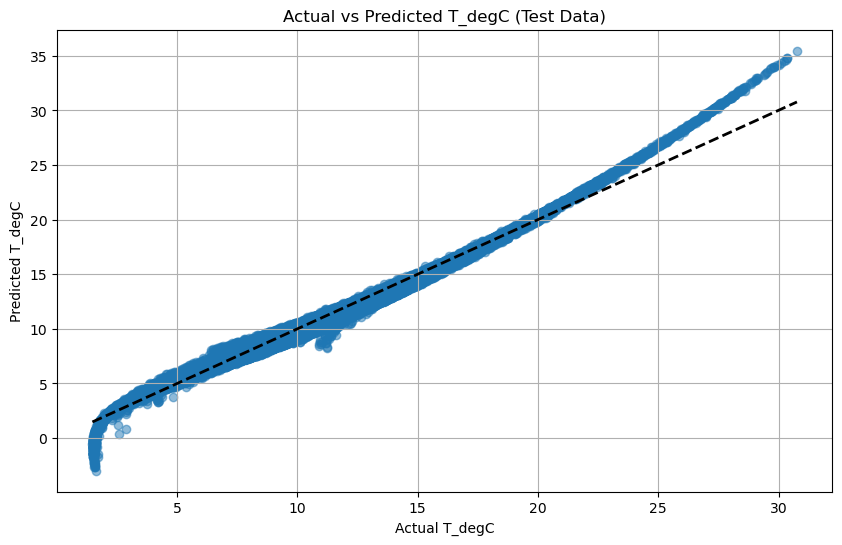

```
theta: [[10.91325175]
 [ 1.6354275 ]
 [-4.63765477]
 [ 0.30285544]
 [-0.48841228]]

Training Data Metrics:
Mean Squared Error: 0.11078570461414351
R-squared: 0.993795184586976
Explained Variance Score: 0.9937954473954191

Test Data Metrics:
Mean Squared Error: 0.11118131940047761
R-squared: 0.9937586989312217
Explained Variance Score: 0.9937595064961333
```

```python
# Function to perform Mini-Batch Gradient Descent

def mini_batch_gradient_descent(X_train, y_train, X_test, y_test, eta=0.1, epochs=100, batch_size=2000):
    # Add a column of 1s to X_train and X_test
    X_train = np.hstack((np.ones((X_train.shape[0], 1)), X_train))
    X_test = np.hstack((np.ones((X_test.shape[0], 1)), X_test))

    # Initialize parameters
    theta = np.random.randn(X_train.shape[1], 1)
    m = len(X_train)

    # Lists to store metrics
    mse_train_list = []
    r2_train_list = []
    ev_train_list = []
    mse_test_list = []
    r2_test_list = []
    ev_test_list = []

    # Mini-Batch Gradient Descent
    for epoch in range(epochs):
        shuffled_indices = np.random.permutation(m)
        X_train_shuffled = X_train[shuffled_indices]
        y_train_shuffled = y_train[shuffled_indices]
        for i in range(0, m, batch_size):
            xi = X_train_shuffled[i:i+batch_size] # This lines extract a mini-batch of training features and labels.
            yi = y_train_shuffled[i:i+batch_size]
            gradients = 2/batch_size * xi.T.dot(xi.dot(theta) - yi)
            # This line computes the gradients of the mean squared error (MSE) cost function with respect to the model parameters (theta) using the current mini-batch.
            theta -= eta * gradients

        # Calculate metrics for training data
        # After completing all mini-batch iterations within an epoch, the code calculates evaluation metrics for the training data (X_train and y_train).
        y_pred_train = X_train.dot(theta)
        mse_train = mean_squared_error(y_train, y_pred_train)
        r2_train = r2_score(y_train, y_pred_train)
        ev_train = explained_variance_score(y_train, y_pred_train)
        mse_train_list.append(mse_train)
        r2_train_list.append(r2_train)
        ev_train_list.append(ev_train)

        # Calculate metrics for test data
        y_pred_test = X_test.dot(theta)
        mse_test = mean_squared_error(y_test, y_pred_test)
        r2_test = r2_score(y_test, y_pred_test)
        ev_test = explained_variance_score(y_test, y_pred_test)
        mse_test_list.append(mse_test)
        r2_test_list.append(r2_test)
        ev_test_list.append(ev_test)

    return {'mse_train': mse_train_list, 'r2_train': r2_train_list, 'ev_train': ev_train_list,
            'mse_test': mse_test_list, 'r2_test': r2_test_list, 'ev_test': ev_test_list,
            'theta': theta}




# Perform Mini-Batch Gradient Descent
result = mini_batch_gradient_descent(X_train_scaled, y_train, X_test_scaled, y_test)

# Add a column of ones to X_test_scaled
X_test_scaled_with_intercept = np.hstack((np.ones((X_test_scaled.shape[0], 1)), X_test_scaled))

# Calculate predictions for the test data using the updated X_test_scaled
y_pred_test = X_test_scaled_with_intercept.dot(result['theta'])

# Plot actual versus predicted values for T_degC for the test data
plt.figure(figsize=(10, 6))
plt.scatter(y_test, y_pred_test, alpha=0.5)
plt.plot([min(y_test), max(y_test)], [min(y_test), max(y_test)], 'k--', lw=2)
plt.title('Actual vs Predicted T_degC (Test Data)')
plt.xlabel('Actual T_degC')
plt.ylabel('Predicted T_degC')
plt.grid(True)
plt.show()

# Print final metrics

print("theta:", result['theta'])

print("\nTraining Data Metrics:")
print("Mean Squared Error:", result['mse_train'][-1])
print("R-squared:", result['r2_train'][-1])
print("Explained Variance Score:", result['ev_train'][-1])
print("\nTest Data Metrics:")
print("Mean Squared Error:", result['mse_test'][-1])
print("R-squared:", result['r2_test'][-1])
print("Explained Variance Score:", result['ev_test'][-1])
```

In each epoch, the training data is shuffled to ensure randomness. The shuffled data is divided into mini-batches, and the model parameters are updated using each mini-batch. After processing all mini-batches, the training performance metrics are computed. This process repeats for the specified number of epochs. In summary, an epoch represents one complete cycle of training, where the model updates its parameters based on all the training data once. The number of epochs determines how many times the algorithm iterates over the entire training dataset during the optimization process.

# Part E: Conceptual Questions

### 1. Describe how parameter estimation in Gradient Descent differs from using the normal equation.

Approach:

Gradient Descent: It is an iterative optimization algorithm that adjusts parameters iteratively in the direction of the **steepest descent of the cost function** until convergence is achieved. Normal Equation: It is a closed-form analytical solution that computes the parameters directly by solving a **system of linear equations**.

Computational Complexity:

Gradient Descent: It can be computationally expensive, especially for large datasets, as it requires multiple iterations to converge to the optimal solution. Normal Equation: It involves matrix multiplication and inversion, which can be computationally expensive for large datasets but provides a direct solution **without the need for iterations**.

Feature Scaling:

Gradient Descent: It often benefits from feature scaling (normalization or standardization) to converge faster and avoid skewed cost function contours. Normal Equation: **Feature scaling is not necessary**, as the solution is derived analytically.

Memory Requirements:

Gradient Descent: It updates parameters iteratively, requiring memory for storing the current parameters and gradients. Normal Equation: It computes parameters directly using matrix operations, which may require storing large matrices in memory, especially for datasets with many features.

Handling Non-linearity:

Gradient Descent: It can handle **complex non-linear relationships between features and the target variable** by using appropriate activation functions in neural networks or polynomial features in linear models. Normal Equation: It provides a linear solution and may not capture non-linear relationships effectively without feature transformations.

Robustness to Ill-Conditioning:

Gradient Descent: It can be more robust to ill-conditioned matrices or singularities in the feature matrix. Normal Equation: It may encounter numerical instability issues, such as matrix singularity, especially when the feature matrix is ill-conditioned or singular.

In summary, Gradient Descent is an iterative optimization method suitable for large datasets and non-linear models, while the normal equation provides a direct solution for parameter estimation but may become impractical for large datasets or ill-conditioned matrices. The choice between the two methods depends on the specific characteristics of the dataset, computational resources, and the desired model complexity.

### 2. We used Mini-Batch Gradient descent here, but there are a variety of options for Gradient Descent. How is Mini-Batch Gradient Descent different from Stochastic Gradient Descent?

Mini-Batch Gradient Descent and Stochastic Gradient Descent (SGD) are both variants of Gradient Descent used for optimizing parameters in machine learning models, but they differ in their approach to updating parameters and the amount of data they use in each iteration:

Batch Size:

Mini-Batch Gradient Descent: It divides the training dataset into small batches of a predefined size (e.g., 32, 64, 128) and **computes the gradient of the cost function using each batch**. Stochastic Gradient Descent (SGD): It uses a batch size of 1, meaning it computes the gradient of the cost function using only one training example at a time.

Parameter Update:

Mini-Batch Gradient Descent: It updates the parameters based on the average gradient computed from the current batch of training examples. Stochastic Gradient Descent (SGD): It **updates the parameters after each individual training example**, leading to more frequent updates but potentially more noisy gradients.

Convergence:

Mini-Batch Gradient Descent: It usually converges faster than SGD because it benefits from parallelization and can take advantage of vectorized operations. Stochastic Gradient Descent (SGD): It can converge faster in terms of processing time per iteration because it processes only one example at a time, but the **convergence may be noisy and erratic due to the variance in gradients**.

Generalization:

Mini-Batch Gradient Descent: It provides a **balance between the stability of batch gradient descent and the efficiency of SGD**, making it more robust and stable in finding good parameter values. Stochastic Gradient Descent (SGD): It tends to have higher variance in parameter updates due to the use of single examples, which may lead to more erratic convergence behavior and poorer generalization performance.

Memory Requirements:

Mini-Batch Gradient Descent: It requires memory to store the current batch of training examples, but the memory requirement is lower than that of batch gradient descent. Stochastic Gradient Descent (SGD): It requires minimal memory as it processes only one training example at a time, making it suitable for large datasets that do not fit into memory.

In summary, Mini-Batch Gradient Descent strikes a **balance between the stability of batch gradient descent and the efficiency of Stochastic Gradient Descent by processing a small batch of training examples at a time**. It offers faster convergence than SGD while being more robust and stable in parameter updates. On the other hand, SGD provides faster updates but with higher variance, making it **more suitable for noisy or non-convex optimization problems**. The choice between the two methods depends on the specific characteristics of the dataset and the computational resources available.

### 3. Identify your best-performing version of Gradient Descent and compare the error metrics for test data vs training data. Does this version of gradient descent show signs of overfitting? Explain.

Efficient Parameter Updates: With a larger batch size, the algorithm computes gradients using more data points, leading to more accurate estimates of the gradient direction. This can result in more efficient parameter updates, allowing the **algorithm to converge faster to the optimal solution**.

Reduced Variance: Larger batch sizes tend to produce less noisy gradient estimates compared to smaller batch sizes. This reduction in variance can lead to more stable convergence and better generalization performancime.

Better Generalization: Although larger batch sizes may result in slower convergence per iteration compared to smaller batch sizes, they often lead to better generalization performance by providing smoother updates to the parameter estimates.

Based on the provided metrics for both training and test data, this version of gradient descent does not show signs of overfitting.

Similar Performance on Training and Test Data:

The mean squared error, R-squared, and explained variance score for both the training and test data are very close to each other. This indicates that the model's performance on unseen test data is comparable to its performance on the training data.

High R-squared and Explained Variance Scores:

The R-squared and explained variance scores are very high for both the training and test data, indicating that the **model captures a significant amount of variance in the target variable. This suggests that the model generalizes well to unseen data and is not overly tailored to the training set**.

Consistent Mean Squared Error:

The mean squared error for both the training and test data is similar, indicating that the model's performance is **consistent across different datasets**. There is no significant discrepancy between the errors on the training and test data, suggesting that the model is not fitting noise in the training data excessively.

No Significant Gap Between Training and Test Performance:

There is no substantial gap between the performance metrics on the training and test data. **If there were signs of overfitting, we would typically expect to see much better performance on the training data compared to the test data.**

### 4. Explain what the learning rate is for. Even though we did not, why might it be helpful to change the learning rate over time?

The learning rate is a hyperparameter that determines the size of the steps taken during the optimization process in gradient-based optimization algorithms such as gradient descent. It controls the magnitude of parameter updates at each iteration and plays a crucial role in determining the convergence speed and stability of the optimization algorithm.

How changing it over time can be helpful?

Controlling Convergence Speed: The learning rate influences how quickly the optimization algorithm converges to the optimal solution. A higher learning rate leads to larger steps, causing faster convergence, while a lower learning rate results in smaller steps and slower convergence. Adjusting the learning rate allows us to **balance the trade-off between convergence speed and stability**.

Stability and Convergence: An appropriate learning rate helps stabilize the optimization process by preventing oscillations or divergence. **Too high a learning rate can cause the algorithm to overshoot the optimal solution or oscillate around it, while too low a learning rate can slow down convergence or get stuck in local minima**.

Adapting to Local Geometry: The learning rate can be adjusted to adapt to the local geometry of the optimization landscape. In regions with steep gradients, **a larger learning rate may be beneficial to make quick progress, while in flatter regions, a smaller learning rate may help navigate more cautiously**.

Handling Non-Convexity: In non-convex optimization problems, the learning rate can influence the ability of the algorithm to escape from local minima and find better solutions. Adaptive learning rate strategies can dynamically **adjust the learning rate based on the curvature of the loss function**, helping the algorithm explore the solution space more effectively.

Avoiding Plateaus and Saddle Points: Changing the learning rate over time can help the optimization algorithm **avoid getting stuck in plateaus or saddle points**, which are regions of the optimization landscape where the gradient is close to zero. By reducing the learning rate in such regions, the algorithm can explore the solution space more thoroughly and potentially escape from suboptimal points.

### 5. Why would a data scientist want to use early stopping in gradient descent?

Data scientists may want to use early stopping in gradient descent to **prevent overfitting and improve the generalization performance of their models**. Here's why early stopping can be beneficial:

Preventing Overfitting: Gradient descent optimization algorithms, especially those used in machine learning models with a large number of parameters (e.g., neural networks), can continue training until they memorize the training data, leading to overfitting. Early stopping allows the model to **halt training before it starts overfitting, thus preventing the model from learning noise in the training data**.

Improving Generalization: By stopping training at an optimal point, early stopping helps the model generalize better to unseen data. It ensures that the model does not become too specialized to the training data and captures the underlying patterns in the data that generalize well to new, unseen examples.

Saving Computational Resources: Early stopping can help save computational resources by stopping training when further iterations are unlikely to significantly improve the model's performance. This is particularly important for large-scale models trained on massive datasets, where training can be time-consuming and resource-intensive.

Simplicity and Interpretability: Early stopping provides a simple and interpretable approach to regularization, as it does not require additional hyperparameters or complex regularization techniques. It offers a straightforward way to prevent overfitting without sacrificing model interpretability.

Reducing Training Time: By terminating training early, data scientists can save time and computational resources, allowing them to **iterate more quickly in model development and experimentation**. This is especially useful in scenarios where rapid prototyping and model iteration are essential.